# Lab 2

Author

Melissa LaMette

# 0. Import the data and declare your package dependencies.

```python
#pip install xlrd
```

```python
import numpy as np
import pandas as pd
import plotnine
from plotnine import *
import matplotlib as plt #only so I can use their fonts within my plotnine boxplots :)

avocados = pd.read_csv("avocado-updated-2020.csv")
avocados
```

|  | date | average_price | total_volume | 4046 | 4225 | 4770 | total_bags | small_bags | large_bags | xlarge_bags | type | year | geography |
| --- | --- | --- | --- | --- | --- | --- | --- | --- | --- | --- | --- | --- | --- |
| 0 | 1/4/15 | 1.22 | 40873.28 | 2819.50 | 28287.42 | 49.90 | 9716.46 | 9186.93 | 529.53 | 0.00 | conventional | 2015 | Albany |
| 1 | 1/4/15 | 1.79 | 1373.95 | 57.42 | 153.88 | 0.00 | 1162.65 | 1162.65 | 0.00 | 0.00 | organic | 2015 | Albany |
| 2 | 1/4/15 | 1.00 | 435021.49 | 364302.39 | 23821.16 | 82.15 | 46815.79 | 16707.15 | 30108.64 | 0.00 | conventional | 2015 | Atlanta |
| 3 | 1/4/15 | 1.76 | 3846.69 | 1500.15 | 938.35 | 0.00 | 1408.19 | 1071.35 | 336.84 | 0.00 | organic | 2015 | Atlanta |
| 4 | 1/4/15 | 1.08 | 788025.06 | 53987.31 | 552906.04 | 39995.03 | 141136.68 | 137146.07 | 3990.61 | 0.00 | conventional | 2015 | Baltimore/Washington |
| ... | ... | ... | ... | ... | ... | ... | ... | ... | ... | ... | ... | ... | ... |
| 33040 | 11/29/20 | 1.47 | 1583056.27 | 67544.48 | 97996.46 | 2617.17 | 1414878.10 | 906711.52 | 480191.83 | 27974.75 | organic | 2020 | Total U.S. |
| 33041 | 11/29/20 | 0.91 | 5811114.22 | 1352877.53 | 589061.83 | 19741.90 | 3790665.29 | 2197611.02 | 1531530.14 | 61524.13 | conventional | 2020 | West |
| 33042 | 11/29/20 | 1.48 | 289961.27 | 13273.75 | 19341.09 | 636.51 | 256709.92 | 122606.21 | 134103.71 | 0.00 | organic | 2020 | West |
| 33043 | 11/29/20 | 0.67 | 822818.75 | 234688.01 | 80205.15 | 10543.63 | 497381.96 | 285764.11 | 210808.02 | 809.83 | conventional | 2020 | West Tex/New Mexico |
| 33044 | 11/29/20 | 1.35 | 24106.58 | 1236.96 | 617.80 | 1564.98 | 20686.84 | 17824.52 | 2862.32 | 0.00 | organic | 2020 | West Tex/New Mexico |

33045 rows × 13 columns

# 1. Briefly describe the data set. What information does it contain?

```python
avocados.head()
```

|  | date | average_price | total_volume | 4046 | 4225 | 4770 | total_bags | small_bags | large_bags | xlarge_bags | type | year | geography |
| --- | --- | --- | --- | --- | --- | --- | --- | --- | --- | --- | --- | --- | --- |
| 0 | 1/4/15 | 1.22 | 40873.28 | 2819.50 | 28287.42 | 49.90 | 9716.46 | 9186.93 | 529.53 | 0.0 | conventional | 2015 | Albany |
| 1 | 1/4/15 | 1.79 | 1373.95 | 57.42 | 153.88 | 0.00 | 1162.65 | 1162.65 | 0.00 | 0.0 | organic | 2015 | Albany |
| 2 | 1/4/15 | 1.00 | 435021.49 | 364302.39 | 23821.16 | 82.15 | 46815.79 | 16707.15 | 30108.64 | 0.0 | conventional | 2015 | Atlanta |
| 3 | 1/4/15 | 1.76 | 3846.69 | 1500.15 | 938.35 | 0.00 | 1408.19 | 1071.35 | 336.84 | 0.0 | organic | 2015 | Atlanta |
| 4 | 1/4/15 | 1.08 | 788025.06 | 53987.31 | 552906.04 | 39995.03 | 141136.68 | 137146.07 | 3990.61 | 0.0 | conventional | 2015 | Baltimore/Washington |

```python
avocados
```

|  | date | average_price | total_volume | 4046 | 4225 | 4770 | total_bags | small_bags | large_bags | xlarge_bags | type | year | geography |
| --- | --- | --- | --- | --- | --- | --- | --- | --- | --- | --- | --- | --- | --- |
| 0 | 1/4/15 | 1.22 | 40873.28 | 2819.50 | 28287.42 | 49.90 | 9716.46 | 9186.93 | 529.53 | 0.00 | conventional | 2015 | Albany |
| 1 | 1/4/15 | 1.79 | 1373.95 | 57.42 | 153.88 | 0.00 | 1162.65 | 1162.65 | 0.00 | 0.00 | organic | 2015 | Albany |
| 2 | 1/4/15 | 1.00 | 435021.49 | 364302.39 | 23821.16 | 82.15 | 46815.79 | 16707.15 | 30108.64 | 0.00 | conventional | 2015 | Atlanta |
| 3 | 1/4/15 | 1.76 | 3846.69 | 1500.15 | 938.35 | 0.00 | 1408.19 | 1071.35 | 336.84 | 0.00 | organic | 2015 | Atlanta |
| 4 | 1/4/15 | 1.08 | 788025.06 | 53987.31 | 552906.04 | 39995.03 | 141136.68 | 137146.07 | 3990.61 | 0.00 | conventional | 2015 | Baltimore/Washington |
| ... | ... | ... | ... | ... | ... | ... | ... | ... | ... | ... | ... | ... | ... |
| 33040 | 11/29/20 | 1.47 | 1583056.27 | 67544.48 | 97996.46 | 2617.17 | 1414878.10 | 906711.52 | 480191.83 | 27974.75 | organic | 2020 | Total U.S. |
| 33041 | 11/29/20 | 0.91 | 5811114.22 | 1352877.53 | 589061.83 | 19741.90 | 3790665.29 | 2197611.02 | 1531530.14 | 61524.13 | conventional | 2020 | West |
| 33042 | 11/29/20 | 1.48 | 289961.27 | 13273.75 | 19341.09 | 636.51 | 256709.92 | 122606.21 | 134103.71 | 0.00 | organic | 2020 | West |
| 33043 | 11/29/20 | 0.67 | 822818.75 | 234688.01 | 80205.15 | 10543.63 | 497381.96 | 285764.11 | 210808.02 | 809.83 | conventional | 2020 | West Tex/New Mexico |
| 33044 | 11/29/20 | 1.35 | 24106.58 | 1236.96 | 617.80 | 1564.98 | 20686.84 | 17824.52 | 2862.32 | 0.00 | organic | 2020 | West Tex/New Mexico |

33045 rows × 13 columns

The purpose of this dataset is to find the city with cheapest avocados???

What are the variables of this dataset and what do they mean? - date is the date of observation - average_price of a single avocado - type of avocado is conventional or organic - year is the year of observation - total volume is. total number of avocadoes sold on that day - 4046, 4225, and 4770 are the total number of avocados with Product Look up codes of the previously stated numbers sold - samll_bags, large_bags, xlarge_bags are the bags the size bags that the avocados were sold in

What are the data types of the variables? date object average_price float64 total_volume float64 4046 float64 4225 float64 4770 float64 total_bags float64 small_bags float64 large_bags float64 xlarge_bags float64 type object year int64 geography object

```python
data_types = avocados.dtypes
data_types
```

```
date              object
average_price    float64
total_volume     float64
4046             float64
4225             float64
4770             float64
total_bags       float64
small_bags       float64
large_bags       float64
xlarge_bags      float64
type              object
year               int64
geography         object
dtype: object
```

# 2. Clean the data in any way you see fit.

```python
avocados["type_geography"] = avocados["geography"].map({
    "Albany" : "city",
    "Atlanta": "city",
    "Baltimore/Washington": "metro area",
    "Boise": "city",
    "Boston": "city",
    "Buffalo/Rochester": "metro area",
    "California": "state",
    "Charlotte": "city",
    "Chicago": "city",
    "Cincinnati/Dayton": "metro area",
    "Columbus": "city",
    "Dallas/Ft. Worth": "metro area",
    "Denver": "city",
    "Detroit": "state",
    "Grand Rapids": "city",
    "Great Lakes": "region",
    "Harrisburg/Scranton": "metro area",
    "Hartford/Springfield": "metro area",
    "Houston": "city",
    "California": "state",
    "Indianapolis": "city",
    "Jacksonville": "city",
    "Las Vegas": "city",
    "Los Angeles": "city",
    "Louisville": "city",
    "Miami/Ft. Lauderdale": "metro area",
    "Midsouth": "region",
    "Nashville": "city",
    "New Orleans/Mobile": "metro area",
    "New York": "city",
    "Northeast": "region",
    "Northern New England": "region",
    "Orlando": "city",
    "Philadelphia": "city",
    "Phoenix/Tucson": "metro area",
    "Pittsburgh": "city",
    "Plains": "region",
    "Portland": "city",
    "Raleign/Greensboro": "metro area",
    "Richmond/Norfolk": "metro area",
    "Roanoke": "city",
    "Sacramento": "city",
    "San Diego": "city",
    "San Francisco": "city",
    "Seattle": "city",
    "South Carolina": "city",
    "Southeast": "region",
    "Spokane": "city",
    "Atlanta": "city",
    "St. Louis": "city",
    "Syracuse": "city",
    "Tampa": "city",
    "Total U.S.": "country",
    "West": "region",
    "West Tex/New Mexico": "metro area"
})

avocados
```

|  | date | average_price | total_volume | 4046 | 4225 | 4770 | total_bags | small_bags | large_bags | xlarge_bags | type | year | geography | type_geography |
| --- | --- | --- | --- | --- | --- | --- | --- | --- | --- | --- | --- | --- | --- | --- |
| 0 | 1/4/15 | 1.22 | 40873.28 | 2819.50 | 28287.42 | 49.90 | 9716.46 | 9186.93 | 529.53 | 0.00 | conventional | 2015 | Albany | city |
| 1 | 1/4/15 | 1.79 | 1373.95 | 57.42 | 153.88 | 0.00 | 1162.65 | 1162.65 | 0.00 | 0.00 | organic | 2015 | Albany | city |
| 2 | 1/4/15 | 1.00 | 435021.49 | 364302.39 | 23821.16 | 82.15 | 46815.79 | 16707.15 | 30108.64 | 0.00 | conventional | 2015 | Atlanta | city |
| 3 | 1/4/15 | 1.76 | 3846.69 | 1500.15 | 938.35 | 0.00 | 1408.19 | 1071.35 | 336.84 | 0.00 | organic | 2015 | Atlanta | city |
| 4 | 1/4/15 | 1.08 | 788025.06 | 53987.31 | 552906.04 | 39995.03 | 141136.68 | 137146.07 | 3990.61 | 0.00 | conventional | 2015 | Baltimore/Washington | metro area |
| ... | ... | ... | ... | ... | ... | ... | ... | ... | ... | ... | ... | ... | ... | ... |
| 33040 | 11/29/20 | 1.47 | 1583056.27 | 67544.48 | 97996.46 | 2617.17 | 1414878.10 | 906711.52 | 480191.83 | 27974.75 | organic | 2020 | Total U.S. | country |
| 33041 | 11/29/20 | 0.91 | 5811114.22 | 1352877.53 | 589061.83 | 19741.90 | 3790665.29 | 2197611.02 | 1531530.14 | 61524.13 | conventional | 2020 | West | region |
| 33042 | 11/29/20 | 1.48 | 289961.27 | 13273.75 | 19341.09 | 636.51 | 256709.92 | 122606.21 | 134103.71 | 0.00 | organic | 2020 | West | region |
| 33043 | 11/29/20 | 0.67 | 822818.75 | 234688.01 | 80205.15 | 10543.63 | 497381.96 | 285764.11 | 210808.02 | 809.83 | conventional | 2020 | West Tex/New Mexico | metro area |
| 33044 | 11/29/20 | 1.35 | 24106.58 | 1236.96 | 617.80 | 1564.98 | 20686.84 | 17824.52 | 2862.32 | 0.00 | organic | 2020 | West Tex/New Mexico | metro area |

33045 rows × 14 columns

```python
avocados = avocados.rename({"4046":"small/medium","4225":"large","4770":"extra large"}, axis = 1)
avocados
```

|  | date | average_price | total_volume | small/medium | large | extra large | total_bags | small_bags | large_bags | xlarge_bags | type | year | geography | type_geography |
| --- | --- | --- | --- | --- | --- | --- | --- | --- | --- | --- | --- | --- | --- | --- |
| 0 | 1/4/15 | 1.22 | 40873.28 | 2819.50 | 28287.42 | 49.90 | 9716.46 | 9186.93 | 529.53 | 0.00 | conventional | 2015 | Albany | city |
| 1 | 1/4/15 | 1.79 | 1373.95 | 57.42 | 153.88 | 0.00 | 1162.65 | 1162.65 | 0.00 | 0.00 | organic | 2015 | Albany | city |
| 2 | 1/4/15 | 1.00 | 435021.49 | 364302.39 | 23821.16 | 82.15 | 46815.79 | 16707.15 | 30108.64 | 0.00 | conventional | 2015 | Atlanta | city |
| 3 | 1/4/15 | 1.76 | 3846.69 | 1500.15 | 938.35 | 0.00 | 1408.19 | 1071.35 | 336.84 | 0.00 | organic | 2015 | Atlanta | city |
| 4 | 1/4/15 | 1.08 | 788025.06 | 53987.31 | 552906.04 | 39995.03 | 141136.68 | 137146.07 | 3990.61 | 0.00 | conventional | 2015 | Baltimore/Washington | metro area |
| ... | ... | ... | ... | ... | ... | ... | ... | ... | ... | ... | ... | ... | ... | ... |
| 33040 | 11/29/20 | 1.47 | 1583056.27 | 67544.48 | 97996.46 | 2617.17 | 1414878.10 | 906711.52 | 480191.83 | 27974.75 | organic | 2020 | Total U.S. | country |
| 33041 | 11/29/20 | 0.91 | 5811114.22 | 1352877.53 | 589061.83 | 19741.90 | 3790665.29 | 2197611.02 | 1531530.14 | 61524.13 | conventional | 2020 | West | region |
| 33042 | 11/29/20 | 1.48 | 289961.27 | 13273.75 | 19341.09 | 636.51 | 256709.92 | 122606.21 | 134103.71 | 0.00 | organic | 2020 | West | region |
| 33043 | 11/29/20 | 0.67 | 822818.75 | 234688.01 | 80205.15 | 10543.63 | 497381.96 | 285764.11 | 210808.02 | 809.83 | conventional | 2020 | West Tex/New Mexico | metro area |
| 33044 | 11/29/20 | 1.35 | 24106.58 | 1236.96 | 617.80 | 1564.98 | 20686.84 | 17824.52 | 2862.32 | 0.00 | organic | 2020 | West Tex/New Mexico | metro area |

33045 rows × 14 columns

```python
avocados = avocados.dropna(axis=0)
avocados
```

|  | date | average_price | total_volume | small/medium | large | extra large | total_bags | small_bags | large_bags | xlarge_bags | type | year | geography | type_geography |
| --- | --- | --- | --- | --- | --- | --- | --- | --- | --- | --- | --- | --- | --- | --- |
| 0 | 1/4/15 | 1.22 | 40873.28 | 2819.50 | 28287.42 | 49.90 | 9716.46 | 9186.93 | 529.53 | 0.00 | conventional | 2015 | Albany | city |
| 1 | 1/4/15 | 1.79 | 1373.95 | 57.42 | 153.88 | 0.00 | 1162.65 | 1162.65 | 0.00 | 0.00 | organic | 2015 | Albany | city |
| 2 | 1/4/15 | 1.00 | 435021.49 | 364302.39 | 23821.16 | 82.15 | 46815.79 | 16707.15 | 30108.64 | 0.00 | conventional | 2015 | Atlanta | city |
| 3 | 1/4/15 | 1.76 | 3846.69 | 1500.15 | 938.35 | 0.00 | 1408.19 | 1071.35 | 336.84 | 0.00 | organic | 2015 | Atlanta | city |
| 4 | 1/4/15 | 1.08 | 788025.06 | 53987.31 | 552906.04 | 39995.03 | 141136.68 | 137146.07 | 3990.61 | 0.00 | conventional | 2015 | Baltimore/Washington | metro area |
| ... | ... | ... | ... | ... | ... | ... | ... | ... | ... | ... | ... | ... | ... | ... |
| 33040 | 11/29/20 | 1.47 | 1583056.27 | 67544.48 | 97996.46 | 2617.17 | 1414878.10 | 906711.52 | 480191.83 | 27974.75 | organic | 2020 | Total U.S. | country |
| 33041 | 11/29/20 | 0.91 | 5811114.22 | 1352877.53 | 589061.83 | 19741.90 | 3790665.29 | 2197611.02 | 1531530.14 | 61524.13 | conventional | 2020 | West | region |
| 33042 | 11/29/20 | 1.48 | 289961.27 | 13273.75 | 19341.09 | 636.51 | 256709.92 | 122606.21 | 134103.71 | 0.00 | organic | 2020 | West | region |
| 33043 | 11/29/20 | 0.67 | 822818.75 | 234688.01 | 80205.15 | 10543.63 | 497381.96 | 285764.11 | 210808.02 | 809.83 | conventional | 2020 | West Tex/New Mexico | metro area |
| 33044 | 11/29/20 | 1.35 | 24106.58 | 1236.96 | 617.80 | 1564.98 | 20686.84 | 17824.52 | 2862.32 | 0.00 | organic | 2020 | West Tex/New Mexico | metro area |

31821 rows × 14 columns

# 3. Which major geographical region sold the most total organic, small Hass avocados in 2017?

Answer = West

```python
aa = avocados[(avocados["type_geography"]=="region") & (avocados["year"]== 2017) & (avocados["type"]== "organic")]
a = aa.groupby('geography').agg({'small/medium': 'sum'}).reset_index()
a.sort_values(by = ["small/medium"], ascending = False)
```

|  | geography | small/medium |
| --- | --- | --- |
| 6 | West | 1870206.29 |
| 2 | Northeast | 925832.36 |
| 5 | Southeast | 285124.34 |
| 0 | Great Lakes | 202487.68 |
| 1 | Midsouth | 186395.50 |
| 4 | Plains | 168583.40 |
| 3 | Northern New England | 1249.48 |

# 4. Split the date variable into month, day, and year variables. In which month is the highest average volume of avocado sales?

Answer = May

```python
avocados['date']= pd.to_datetime(avocados['date'])

avocados['day'] = avocados['date'].dt.day
avocados['month'] = avocados['date'].dt.month
avocados
avocados_1 = avocados.groupby('month').agg({'total_volume': 'mean'}).reset_index()
avocados_1.sort_values(by = ["total_volume"], ascending = False)
```

[output not shown]

|  | month | total_volume |
| --- | --- | --- |
| 4 | 5 | 1.087944e+06 |
| 1 | 2 | 1.061659e+06 |
| 5 | 6 | 1.018239e+06 |
| 3 | 4 | 9.808371e+05 |
| 2 | 3 | 9.624036e+05 |
| 0 | 1 | 9.560299e+05 |
| 6 | 7 | 9.523387e+05 |
| 7 | 8 | 9.190774e+05 |
| 8 | 9 | 8.755127e+05 |
| 9 | 10 | 8.160455e+05 |
| 10 | 11 | 7.957336e+05 |
| 11 | 12 | 7.810201e+05 |

# 5. Which metro area geographical regions sold the most total avocados?

Answer: Dallas/Fortworth #Plot side by side box plots of the total volume for only the five metro geographical regions with the highest averages for the total_volume variable.

```python
ma = avocados[avocados["type_geography"] == "metro area"]
a = ma.groupby('geography').agg({'total_volume': 'sum'}).reset_index()
a.sort_values(by = ["total_volume"], ascending = False)
```

|  | geography | total_volume |
| --- | --- | --- |
| 3 | Dallas/Ft. Worth | 4.362042e+08 |
| 8 | Phoenix/Tucson | 3.825234e+08 |
| 10 | West Tex/New Mexico | 2.806116e+08 |
| 0 | Baltimore/Washington | 2.767646e+08 |
| 6 | Miami/Ft. Lauderdale | 2.317448e+08 |
| 5 | Hartford/Springfield | 1.046050e+08 |
| 7 | New Orleans/Mobile | 9.466657e+07 |
| 4 | Harrisburg/Scranton | 9.397640e+07 |
| 2 | Cincinnati/Dayton | 9.273281e+07 |
| 9 | Richmond/Norfolk | 9.124998e+07 |
| 1 | Buffalo/Rochester | 5.120092e+07 |

##Plot side by side box plots of the total volume for only the five metro geographical regions with the highest averages for the total_volume variable.

```python
top_five = ma[(ma['geography'] == 'Baltimore/Washington') | (ma['geography']== 'Dallas/Ft. Worth') |(ma['geography']== 'Phoenix/Tucson') |
 (ma['geography']== 'West Tex/New Mexico') | (ma['geography']== 'Miami/Ft. Lauderdale') ]
top_five
```

|  | date | average_price | total_volume | small/medium | large | extra large | total_bags | small_bags | large_bags | xlarge_bags | type | year | geography | type_geography | day | month |
| --- | --- | --- | --- | --- | --- | --- | --- | --- | --- | --- | --- | --- | --- | --- | --- | --- |
| 4 | 2015-01-04 | 1.08 | 788025.06 | 53987.31 | 552906.04 | 39995.03 | 141136.68 | 137146.07 | 3990.61 | 0.00 | conventional | 2015 | Baltimore/Washington | metro area | 4 | 1 |
| 5 | 2015-01-04 | 1.29 | 19137.28 | 8040.64 | 6557.47 | 657.48 | 3881.69 | 3881.69 | 0.00 | 0.00 | organic | 2015 | Baltimore/Washington | metro area | 4 | 1 |
| 22 | 2015-01-04 | 0.74 | 1086363.97 | 612795.80 | 374420.68 | 9817.28 | 89330.21 | 54563.33 | 34760.08 | 6.80 | conventional | 2015 | Dallas/Ft. Worth | metro area | 4 | 1 |
| 23 | 2015-01-04 | 1.35 | 9895.96 | 4634.70 | 1647.92 | 0.00 | 3613.34 | 3613.34 | 0.00 | 0.00 | organic | 2015 | Dallas/Ft. Worth | metro area | 4 | 1 |
| 48 | 2015-01-04 | 0.97 | 540234.22 | 398670.03 | 54844.33 | 39.07 | 86680.79 | 38505.18 | 48175.61 | 0.00 | conventional | 2015 | Miami/Ft. Lauderdale | metro area | 4 | 1 |
| ... | ... | ... | ... | ... | ... | ... | ... | ... | ... | ... | ... | ... | ... | ... | ... | ... |
| 32986 | 2020-11-29 | 0.96 | 15705.31 | 157.95 | 0.00 | 0.00 | 15547.36 | 14310.69 | 0.00 | 1236.67 | organic | 2020 | Miami/Ft. Lauderdale | metro area | 29 | 11 |
| 33003 | 2020-11-29 | 0.76 | 936684.60 | 309280.89 | 120280.85 | 3730.15 | 503392.71 | 222668.00 | 280622.22 | 102.49 | conventional | 2020 | Phoenix/Tucson | metro area | 29 | 11 |
| 33004 | 2020-11-29 | 1.30 | 24377.24 | 2397.86 | 714.68 | 0.00 | 21264.70 | 14368.89 | 6895.81 | 0.00 | organic | 2020 | Phoenix/Tucson | metro area | 29 | 11 |
| 33043 | 2020-11-29 | 0.67 | 822818.75 | 234688.01 | 80205.15 | 10543.63 | 497381.96 | 285764.11 | 210808.02 | 809.83 | conventional | 2020 | West Tex/New Mexico | metro area | 29 | 11 |
| 33044 | 2020-11-29 | 1.35 | 24106.58 | 1236.96 | 617.80 | 1564.98 | 20686.84 | 17824.52 | 2862.32 | 0.00 | organic | 2020 | West Tex/New Mexico | metro area | 29 | 11 |

3057 rows × 16 columns

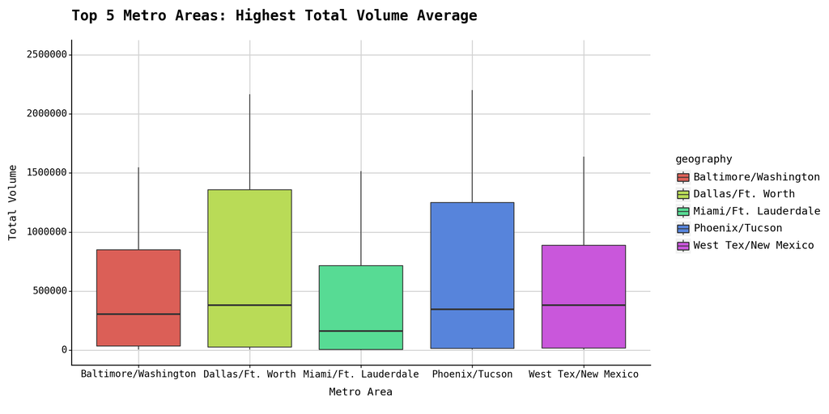

```
<Figure Size: (1200 x 600)>
```

```python
mab = (ggplot(top_five, aes("geography", "total_volume", fill = 'geography'))
+ geom_boxplot()
+ xlab("Metro Area")
+ ylab("Total Volume")
+ scale_y_continuous(breaks=np.arange(0, 2500001, 500000), limits=[0, 2500000])
+ ggtitle("Top 5 Metro Areas: Highest Total Volume Average")
#+ theme_bw()
+ theme(
        axis_line=element_line(size=1, colour="black"),
        panel_grid_major=element_line(colour="#d3d3d3"),
        panel_grid_minor=element_blank(),
        panel_border=element_blank(),
        panel_background=element_blank(),
        plot_title=element_text(size=15, family="monospace",
                                face="bold"),
        text=element_text(family="monospace", size=11),
        axis_text_x=element_text(colour="black", size=10),
        axis_text_y=element_text(colour="black", size=10),
    )
+ theme(figure_size = (12,6)))
mab
```

# 6. From your cleaned data set, create a data set with only these California regions and answer the following questions about these California regions only.

- Los Angeles
- San Diego
- Sacramento
- San Francisco

```python
cali_regions = avocados[(avocados['geography'] == 'Los Angeles') | (avocados['geography']== 'San Diego') |(avocados['geography']== 'Sacramento') |
 (avocados['geography']== 'San Francisco')]
cali_regions
```

|  | date | average_price | total_volume | small/medium | large | extra large | total_bags | small_bags | large_bags | xlarge_bags | type | year | geography | type_geography | day | month |
| --- | --- | --- | --- | --- | --- | --- | --- | --- | --- | --- | --- | --- | --- | --- | --- | --- |
| 44 | 2015-01-04 | 0.85 | 2682159.95 | 1837999.65 | 524430.47 | 64225.78 | 255504.05 | 215571.80 | 36981.72 | 2950.53 | conventional | 2015 | Los Angeles | city | 4 | 1 |
| 45 | 2015-01-04 | 1.25 | 54495.54 | 47721.51 | 1723.40 | 0.00 | 5050.63 | 5050.63 | 0.00 | 0.00 | organic | 2015 | Los Angeles | city | 4 | 1 |
| 80 | 2015-01-04 | 1.05 | 430138.88 | 110693.69 | 270107.61 | 9737.50 | 39600.08 | 39600.08 | 0.00 | 0.00 | conventional | 2015 | Sacramento | city | 4 | 1 |
| 81 | 2015-01-04 | 1.33 | 9213.49 | 3727.52 | 4327.52 | 0.00 | 1158.45 | 1158.45 | 0.00 | 0.00 | organic | 2015 | Sacramento | city | 4 | 1 |
| 82 | 2015-01-04 | 0.94 | 461607.33 | 244152.26 | 165299.33 | 15302.75 | 36852.99 | 30884.29 | 5595.00 | 373.70 | conventional | 2015 | San Diego | city | 4 | 1 |
| ... | ... | ... | ... | ... | ... | ... | ... | ... | ... | ... | ... | ... | ... | ... | ... | ... |
| 33018 | 2020-11-29 | 1.43 | 23531.38 | 3303.69 | 2057.03 | 0.00 | 18170.66 | 18144.54 | 26.12 | 0.00 | organic | 2020 | Sacramento | city | 29 | 11 |
| 33019 | 2020-11-29 | 1.12 | 469356.72 | 104509.99 | 19988.45 | 7210.47 | 337647.81 | 189341.36 | 127701.64 | 20604.81 | conventional | 2020 | San Diego | city | 29 | 11 |
| 33020 | 2020-11-29 | 1.95 | 25799.95 | 894.63 | 838.11 | 0.00 | 24067.21 | 9691.46 | 14375.75 | 0.00 | organic | 2020 | San Diego | city | 29 | 11 |
| 33021 | 2020-11-29 | 1.50 | 644141.37 | 128555.43 | 136718.24 | 5597.21 | 373270.49 | 159276.65 | 207760.32 | 6233.52 | conventional | 2020 | San Francisco | city | 29 | 11 |
| 33022 | 2020-11-29 | 1.87 | 59527.02 | 2815.23 | 4542.30 | 0.00 | 52169.49 | 52034.33 | 135.16 | 0.00 | organic | 2020 | San Francisco | city | 29 | 11 |

2448 rows × 16 columns

# 7. In which California regions is the price of organic versus conventional avocados most different? Support your answer with a few summary statistics AND a visualization?

Answer: San Francisco

```python
differences = pd.crosstab(cali_regions['geography'], columns = cali_regions['type'], values = cali_regions['average_price'], aggfunc = 'mean')
differences['price_difference'] = differences['conventional']-differences['organic']
differences['price_difference'] = differences['price_difference'].abs() #make the differences positive
differences = differences.reset_index()
differences.columns.name = None
differences
```

|  | geography | conventional | organic | price_difference |
| --- | --- | --- | --- | --- |
| 0 | Los Angeles | 1.047124 | 1.574902 | 0.527778 |
| 1 | Sacramento | 1.295359 | 1.873856 | 0.578497 |
| 2 | San Diego | 1.113856 | 1.798366 | 0.684510 |
| 3 | San Francisco | 1.400490 | 2.119444 | 0.718954 |

```python
#visualization
#Los Angeles
la = cali_regions[cali_regions['geography']=='Los Angeles']
la = la.loc[:,['average_price','type','geography','year']]
o = la[la['type']=='organic']
c = la[la['type']=='conventional']
ladiff = o.merge(c, on=['year'])
ladiff['differences'] = ladiff['average_price_x']-ladiff['average_price_y']
ladiff

#Sacramento
sac = cali_regions[cali_regions['geography']=='Sacramento']
sac = sac.loc[:,['average_price','type','geography','year']]
o = sac[sac['type']=='organic']
c = sac[sac['type']=='conventional']
sacdiff = o.merge(c, on=['year'])
sacdiff['differences'] = sacdiff['average_price_x']-sacdiff['average_price_y']
sacdiff

#San Diego
sd = cali_regions[cali_regions['geography']=='San Diego']
sd = sd.loc[:,['average_price','type','geography','year']]
o = sd[sd['type']=='organic']
c = sd[sd['type']=='conventional']
sddiff = o.merge(c, on=['year'])
sddiff['differences'] = sddiff['average_price_x']-sddiff['average_price_y']
sddiff

#San Francisco
sf = cali_regions[cali_regions['geography']=='San Francisco']
sf = sf.loc[:,['average_price','type','geography','year']]
o = sf[sf['type']=='organic']
c = sf[sf['type']=='conventional']
sfdiff = o.merge(c, on=['year'])
sfdiff['differences'] = sfdiff['average_price_x']-sfdiff['average_price_y']
sfdiff

differences = pd.concat([ladiff,sacdiff,sddiff,sfdiff],ignore_index=True)
differences.rename(columns = {'differences':'price_diff_ovsc'}, inplace=True)
differences
```

|  | average_price_x | type_x | geography_x | year | average_price_y | type_y | geography_y | price_diff_ovsc |
| --- | --- | --- | --- | --- | --- | --- | --- | --- |
| 0 | 1.25 | organic | Los Angeles | 2015 | 0.85 | conventional | Los Angeles | 0.40 |
| 1 | 1.25 | organic | Los Angeles | 2015 | 0.85 | conventional | Los Angeles | 0.40 |
| 2 | 1.25 | organic | Los Angeles | 2015 | 0.89 | conventional | Los Angeles | 0.36 |
| 3 | 1.25 | organic | Los Angeles | 2015 | 0.96 | conventional | Los Angeles | 0.29 |
| 4 | 1.25 | organic | Los Angeles | 2015 | 0.74 | conventional | Los Angeles | 0.51 |
| ... | ... | ... | ... | ... | ... | ... | ... | ... |
| 62499 | 1.87 | organic | San Francisco | 2020 | 1.34 | conventional | San Francisco | 0.53 |
| 62500 | 1.87 | organic | San Francisco | 2020 | 1.00 | conventional | San Francisco | 0.87 |
| 62501 | 1.87 | organic | San Francisco | 2020 | 1.28 | conventional | San Francisco | 0.59 |
| 62502 | 1.87 | organic | San Francisco | 2020 | 1.28 | conventional | San Francisco | 0.59 |
| 62503 | 1.87 | organic | San Francisco | 2020 | 1.50 | conventional | San Francisco | 0.37 |

62504 rows × 8 columns

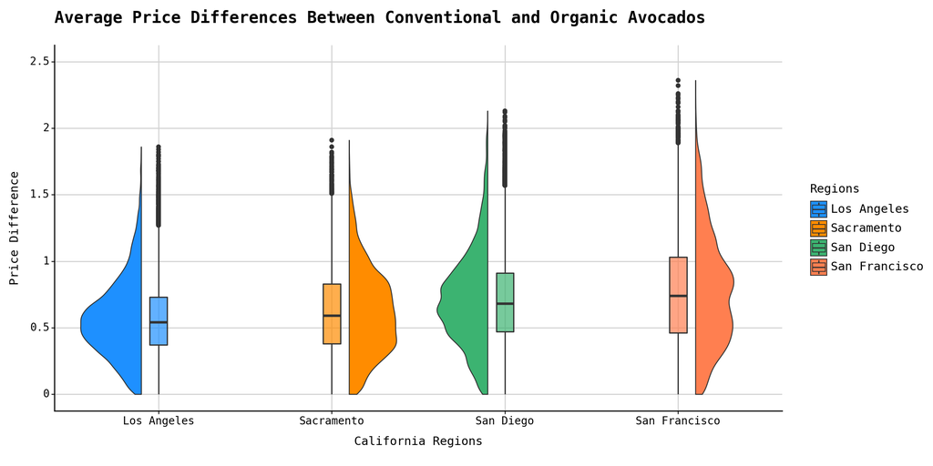

```
<Figure Size: (1200 x 600)>
```

```python
shift = 0.1
mean_values = differences

def alt_sign(x): #created a function to move it
    "Alternate +1/-1 if x is even/odd"
    return (-1) ** x

m1 = aes(x=stage('geography_x', after_scale='x+shift*alt_sign(x)'))

d = (ggplot(differences, aes(x = 'geography_x',y ='price_diff_ovsc', fill = 'geography_x'))
+ geom_violin(m1, style = 'left-right')
+ geom_boxplot(width = 0.1, alpha = 0.7, size = 0.65)
+ xlab("California Regions")
+ ylab("Price Difference")
+ labs(fill = "Regions")
+ ggtitle("Average Price Differences Between Conventional and Organic Avocados")
+ scale_y_continuous(breaks=np.arange(0, 2.6, 0.5), limits=[0, 2.5])
+ scale_fill_manual(values=['dodgerblue', 'darkorange', 'mediumseagreen','coral'])
+theme(
        axis_line=element_line(size=1, colour="black"),
        panel_grid_major=element_line(colour="#d3d3d3"),
        panel_grid_minor=element_blank(),
        panel_border=element_blank(),
        panel_background=element_blank(),
        plot_title=element_text(size=15, family="monospace",
                                face="bold"),
        text=element_text(family="monospace", size=11),
        axis_text_x=element_text(colour="black", size=10),
        axis_text_y=element_text(colour="black", size=10),
    )
+ theme(figure_size = (12,6)))
d

#still need the multiple observations from the dataset
```